# Text Mining & Image Recognition, Seccion B

# LABORATORIO No.1

**Alumno:** Felipe Carlos Escoto Castro

```python
import cv2
import matplotlib.pyplot as plt
import numpy as np
```

```python
img = cv2.imread("bananero.jpg")
img = cv2.cvtColor(img, cv2.COLOR_BGR2RGB)
```

```
<function matplotlib.pyplot.show(close=None, block=None)>
```

[figure not shown]

```python
plt.imshow(img)
plt.axis('off')
plt.show
```

# Problema 1:

Creamos la funcion

```python
def cambio_color(img, color):
    img_salida = np.zeros_like(img)
    alto = img.shape[0]
    ancho = img.shape[1]

    for i in range(0, alto):
        for j in range(0, ancho):
            pixel = img[i,j]

            blue = pixel[2]
            green = pixel[1]
            red = pixel[0]

            if color == 1:
                img_salida[i,j] = [0,0,blue] # color azul
            elif color == 2:
                img_salida[i,j] = [0,green,0] # color verde
            elif color == 3:
                img_salida[i,j] = [red,0,0] # color rojo
            elif color == 10:
                img_salida[i,j] = [red,green,0] # color Rojo y verde
            elif color == 20:
                img_salida[i,j] = [0,green,blue] # Verde y azul
            elif color == 30:
                img_salida[i,j] = [red,0,blue] # Azul y rojo

    return img_salida
```

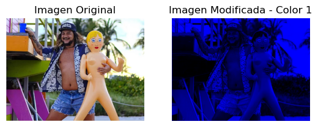

```python
# Definir los números permitidos
numeros_permitidos = [1, 2, 3, 10, 20, 30]

# Solicitar al usuario que ingrese un número válido
while True:
    try:
        numero = int(input("Por favor, ingresa un número (1, 2, 3, 10, 20, 30): "))
        if numero in numeros_permitidos:
            color = numero

            # Mostrar la imagen original
            plt.subplot(1, 2, 1)
            plt.title("Imagen Original")
            plt.axis('off')
            plt.imshow(img)

            # Modificar la imagen según el color ingresado
            img_modificada = cambio_color(img, color)
            plt.subplot(1, 2, 2)
            plt.title(f"Imagen Modificada - Color {color}")
            plt.axis('off')
            plt.imshow(img_modificada)

            plt.show()
            break
        else:
            print("Número no permitido. Intenta de nuevo.")
    except ValueError:
        print("Entrada no válida. Por favor, ingresa un número.")
```

### Problema 2

#### Creamos la funcion

```python
def crear_img_color(img_rojo, img_verde, img_azul):

    #creamos una imagen vacia con tres canales
    img_color = np.zeros((img_rojo.shape[0], img_rojo.shape[1],3), dtype=np.uint8)
    alto = img_rojo.shape[0]
    ancho = img_rojo.shape[1]

    for i in range(alto):
        for j in range(ancho):
            #asignar cada imagen de escala de grises a su respectivo canal de color
            img_color[i,j] = [img_rojo[i,j], img_verde[i,j], img_azul[i,j]]

    return img_color
```

#### Imagen 1

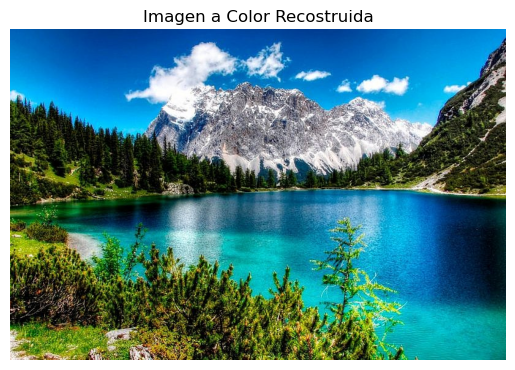

```python
# Leemops las imagenes en escala de grises
img_rojo = cv2.imread("imagen1_salida_gray_rojo.jpg", cv2.IMREAD_GRAYSCALE)
img_verde = cv2.imread("imagen1_salida_gray_verde.jpg", cv2.IMREAD_GRAYSCALE)
img_azul = cv2.imread("imagen1_salida_gray_azul.jpg", cv2.IMREAD_GRAYSCALE)

# Creamos la imagen resultante
img_color = crear_img_color(img_azul, img_verde, img_rojo)

# Mostramos la imagen resultante
plt.imshow(cv2.cvtColor(img_color, cv2.COLOR_BGR2RGB))
plt.title("Imagen a Color Recostruida")
plt.axis('off')
plt.show()
```

#### Imagen 2

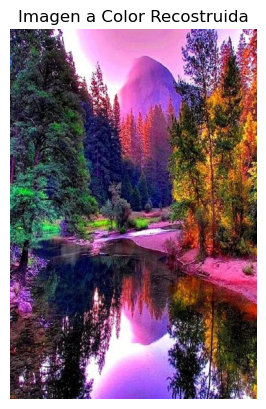

```python
# Leemops las imagenes en escala de grises
img_rojo = cv2.imread("imagen2_salida_gray_rojo.jpg", cv2.IMREAD_GRAYSCALE)
img_verde = cv2.imread("imagen2_salida_gray_verde.jpg", cv2.IMREAD_GRAYSCALE)
img_azul = cv2.imread("imagen2_salida_gray_azul.jpg", cv2.IMREAD_GRAYSCALE)

# Creamos la imagen resultante
img_color = crear_img_color(img_azul, img_verde, img_rojo)

# Mostramos la imagen resultante
plt.imshow(cv2.cvtColor(img_color, cv2.COLOR_BGR2RGB))
plt.title("Imagen a Color Recostruida")
plt.axis('off')
plt.show()
```

### Imagen3

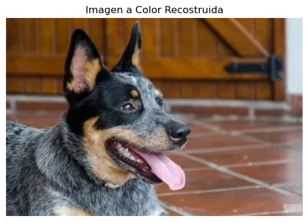

```python
# Leemops las imagenes en escala de grises
img_rojo = cv2.imread("perro_salida_gray_rojo.jpg", cv2.IMREAD_GRAYSCALE)
img_verde = cv2.imread("perro_salida_gray_verde.jpg", cv2.IMREAD_GRAYSCALE)
img_azul = cv2.imread("perro_salida_gray_azul.jpg", cv2.IMREAD_GRAYSCALE)

# Creamos la imagen resultante
img_color = crear_img_color(img_azul, img_verde, img_rojo)

# Mostramos la imagen resultante
plt.imshow(cv2.cvtColor(img_color, cv2.COLOR_BGR2RGB))
plt.title("Imagen a Color Recostruida")
plt.axis('off')
plt.show()
```

### Problema 3

```python
def crear_imagenes_gray_por_canal(imagen_a_color):
    #Separamos los canales de la imagen
    imagen_azul, imagen_verde, imagen_rojo = cv2.split(imagen_a_color)
    alto = imagen_a_color.shape[0]
    ancho = imagen_a_color.shape[1]

    img_gray_rojo = np.zeros((alto, ancho), dtype=np.uint8)
    img_gray_verde = np.zeros((alto, ancho), dtype=np.uint8)
    img_gray_azul = np.zeros((alto, ancho), dtype=np.uint8)

    for i in range(alto):
        for j in range(ancho):
            #Obtner el valor del pixel en cada canal
            pixel_rojo = imagen_rojo[i,j]
            pixel_verde = imagen_verde[i,j]
            pixel_azul = imagen_azul[i,j]

            #Asignar el valor del pixel a la imagen de escala de grises correspondiente
            img_gray_rojo[i,j] = pixel_rojo
            img_gray_verde[i,j] = pixel_verde
            img_gray_azul[i,j] = pixel_azul

    return img_gray_rojo, img_gray_verde, img_gray_azul
```

[figure not shown]

```python
img_gray_rojo, img_gray_verde, img_gray_azul = crear_imagenes_gray_por_canal(img)

plt.figure(figsize=(12, 4))

plt.subplot(1, 3, 1)
plt.imshow(img_gray_rojo, cmap='gray')
plt.title("Canal Rojo")
plt.axis('off')

plt.subplot(1, 3, 2)
plt.imshow(img_gray_verde, cmap='gray')
plt.title("Canal Verde")
plt.axis('off')

plt.subplot(1, 3, 3)
plt.imshow(img_gray_azul, cmap='gray')
plt.title("Canal Azul")
plt.axis('off')

plt.show()
```

### Problema 4

```python
def mostrar_histogramas(imagen_color):
    # Separar los canales de la imagen
    imagen_azul, imagen_verde, imagen_rojo = cv2.split(imagen_color)

    # Convertir a escala de grises (promedio aritmético)
    imagen_gris = (imagen_azul.astype(float) + imagen_verde.astype(float) + imagen_rojo.astype(float)) / 3
    imagen_gris = imagen_gris.astype(np.uint8)

    # Calcular histogramas
    hist_azul, bins_azul= np.histogram(imagen_azul, bins=256,range=[0, 256])
    hist_verde, bins_verde = np.histogram(imagen_verde, bins=256, range=[0, 256])
    hist_rojo, bins_rojo = np.histogram(imagen_rojo, bins=256, range=[0, 256])
    hist_gris, bins_gris = np.histogram(imagen_gris, bins=256, range=[0, 256])

    # Calcular medias
    media_azul = np.mean(imagen_azul)
    media_verde = np.mean(imagen_verde)
    media_rojo = np.mean(imagen_rojo)
    media_gris = np.mean(imagen_gris)

    # Crear subplots para los histogramas
    fig, axs = plt.subplots(2, 2, figsize=(12, 10))
    axs = axs.ravel()

    # Histograma del canal azul
    axs[0].plot(bins_azul [:-1],hist_azul, color='blue')
    axs[0].axvline(media_azul, color='blue', linestyle='--')
    axs[0].set_title('Histograma Color Azul')


    # Histograma del canal verde
    axs[1].plot(bins_verde [:-1], hist_verde, color='green')
    axs[1].axvline(media_verde, color='green', linestyle='--')
    axs[1].set_title('Histograma Color Verde')

    # Histograma del canal rojo
    axs[2].plot(bins_rojo[:-1], hist_rojo, color='red')
    axs[2].axvline(media_rojo, color='red', linestyle='--')
    axs[2].set_title('Histograma Color Rojo')

    # Histograma de la imagen en escala de grises
    axs[3].plot(bins_gris[:-1], hist_gris, color='gray')
    axs[3].axvline(media_gris, color='gray', linestyle='--')
    axs[3].set_title('Histograma Escala de Grises')

    plt.show()
```

[figure not shown]

```python
# Ejemplo de uso
mostrar_histogramas(img)
```

### Problema 5

Escala de grises ponderado

El enfoque de escala de grises ponderado es una técnica utilizada para convertir imágenes en color a escala de grises, teniendo en cuenta la contribución relativa de cada componente de color (rojo, verde y azul) al valor final del gris. Este método utiliza coeficientes ponderados para cada canal de color en lugar de simplemente promediar los valores de los canales.

Concepto La idea detrás del enfoque ponderado es que los colores se perciben de manera diferente por el ojo humano, y no todos los colores tienen la misma importancia al convertir a escala de grises. Por ejemplo, el ojo humano es más sensible a los verdes que a los rojos o azules, por lo que se le asigna un mayor peso al componente verde.

Un enfoque comúnmente utilizado para la conversión ponderada es el que sigue la fórmula de luminancia:

Gris=0.299⋅R+0.587⋅G+0.114⋅B

Aquí:

*R es el componente rojo,* G es el componente verde, *B es el componente azul.

Estos coeficientes se basan en la sensibilidad del ojo humano a cada color.

```python
from PIL import Image


def convertir_a_grises_ponderado(imagen_color):
    # Cargar la imagen
    imagen = Image.open(imagen_color)

    # Convertir la imagen a un array numpy
    imagen_array = np.array(imagen)

    # Definir los coeficientes ponderados
    coeficientes = np.array([0.299, 0.587, 0.114])

    # Aplicar la transformación ponderada
    imagen_gris_array = np.dot(imagen_array[...,:3], coeficientes)

    # Convertir el array a una imagen
    imagen_gris = Image.fromarray(imagen_gris_array.astype(np.uint8))

    return imagen_gris

# Usar la función para convertir una imagen a escala de grises
imagen_gris = convertir_a_grises_ponderado('bananero.jpg')
imagen_gris.show()
```

### Problema 6

# Espacio de Color HSV

El espacio de color HSV (Hue, Saturation, Value) es un modelo de representación de colores basado en tres componentes:

## Hue (Tono)

Representa el color en sí mismo. El tono se mide en grados en un círculo de 360 grados, donde:

- 0° o 360° representa el rojo,
- 120° representa el verde,
- 240° representa el azul,

y así sucesivamente. El tono define el color base.

## Saturation (Saturación)

Indica la intensidad o pureza del color. La saturación varía del 0% al 100%, donde:

- 0% corresponde a un color gris (sin saturación),
- 100% representa el color puro.

## Value (Valor o Brillo)

Representa la luminosidad o el brillo del color. El valor también varía del 0% al 100%, donde:

- 0% es completamente oscuro (negro),
- 100% es el color más brillante.

## Mapeo de Colores a HSV

Para mapear colores al espacio HSV, debes tener en cuenta que este espacio se utiliza comúnmente como una representación alternativa al espacio RGB (Red, Green, Blue), especialmente en aplicaciones de edición de imágenes y diseño gráfico debido a su relación más intuitiva con la percepción humana del color.

## Conversión de RGB a HSV

Para convertir colores de RGB a HSV, puedes utilizar las siguientes fórmulas:

### Normalización de RGB

Convierte los valores RGB (que van de 0 a 255) a valores en el rango [0, 1].

[output not shown]